# NoteBook

Edilmo Palencia

# Task 0 - Obtaining the data & Familiarizing with NLP

The corpus:

```
## Time difference of 0.02287889 secs
```

|  | src | lan | src-type | f-name | f-path |
| --- | --- | --- | --- | --- | --- |
| r | HC Corpora | de_DE | blogs | de_DE.blogs.txt | corpus/HC Corpora/de_DE/de_DE.blogs.txt |
| r | HC Corpora | de_DE | news | de_DE.news.txt | corpus/HC Corpora/de_DE/de_DE.news.txt |
| r | HC Corpora | de_DE | twitter | de_DE.twitter.txt | corpus/HC Corpora/de_DE/de_DE.twitter.txt |
| r | HC Corpora | en_US | blogs | en_US.blogs.txt | corpus/HC Corpora/en_US/en_US.blogs.txt |
| r | HC Corpora | en_US | news | en_US.news.txt | corpus/HC Corpora/en_US/en_US.news.txt |
| r | HC Corpora | en_US | twitter | en_US.twitter.txt | corpus/HC Corpora/en_US/en_US.twitter.txt |
| r | HC Corpora | fi_FI | blogs | fi_FI.blogs.txt | corpus/HC Corpora/fi_FI/fi_FI.blogs.txt |
| r | HC Corpora | fi_FI | news | fi_FI.news.txt | corpus/HC Corpora/fi_FI/fi_FI.news.txt |
| r | HC Corpora | fi_FI | twitter | fi_FI.twitter.txt | corpus/HC Corpora/fi_FI/fi_FI.twitter.txt |
| r | HC Corpora | ru_RU | blogs | ru_RU.blogs.txt | corpus/HC Corpora/ru_RU/ru_RU.blogs.txt |
| r | HC Corpora | ru_RU | news | ru_RU.news.txt | corpus/HC Corpora/ru_RU/ru_RU.news.txt |
| r | HC Corpora | ru_RU | twitter | ru_RU.twitter.txt | corpus/HC Corpora/ru_RU/ru_RU.twitter.txt |

## Questions about the HC Corpora

```
## Time difference of 1.352151 mins
```

```
## Time difference of 1.026111 mins
```

1. The en_US.blogs.txt file is how many megabytes?
   - Araoud 197.2432184 Mega bytes.
2. The en_US.twitter.txt has how many lines of text?
   - Araoud 2.360148 million lines.
3. What is the length of the longest line seen in any of the three en_US data sets?
   - EnUSblogs 40833
   - EnUSnews 11384
   - EnUStwitter 140
4. In the en_US twitter data set, if you divide the number of lines where the word “love” (all lowercase) occurs by the number of lines the word “hate” (all lowercase) occurs, about what do you get?
   - 4.1085916
5. The one tweet in the en_US twitter data set that matches the word “biostats” says what?
   - i know how you feel.. i have biostats on tuesday and i have yet to study =/
6. How many tweets have the exact characters “A computer once beat me at chess, but it was no match for me at kickboxing”. (I.e. the line matches those characters exactly.)
   - 3
7. What does the data look like?
   - The data present in the corpus is completed unstructured documents of natural language texts in 4 languages. There are no pre-proccessing actions taken.
8. Where does the data come from?
   - The data comes from 3 kind of sources: news articles, blogs and tweets.
9. Can you think of any other data sources that might help you in this project?
   - Dictionaries, theasaurus and ontologies.
10. What are the common steps in natural language processing?
    - Tokenize: corpus segmentation and transformation.
      - Word separation
      - Multi-word recognition
      - Character n-gram
      - Lexicon matching
      - Punctuation handling
      - Stop-words ignoring
      - Hyphenation handling
    - Normalize: many different strings convey identical meanings.
      - Case folding: problematic because case and accent change meaning sometimes.
      - Stemming: problematic because agglutinative languages has many concepts combined in a single word.
      - Lemmatize.
      - Profanity Handling.
    - Annotation: identical strings may have different meaning.
      - Part of the speech tagging.
      - Word sense tagging.
      - Parsing: making words according to their grammatical role.
11. What are some common issues in the analysis of text data?
    - Polysemy: it is the capacity of a sign to have multiple meanings.
    - Paralanguage recognition: component of meta-communication that may modify or nuance meaning, or convey emotion.
    - Curse of dimensionality - Data Sparsity: curse of dimensionality are problems that arise when the data is high dimensional. Data sparsity is specific problem that happens when exist a lot of dimension combinations that are not populated at all (maybe because it doesn’t make any sense or just because the data set is incomplete).
    - Noisy Morphological Segmentation: morphological analysis is the task of segmenting a word into morphemes, the smallest meaning- bearing elements of natural languages. Normally this can be spoiled for orthographic errors and so.
    - Order-Invariance of Factor Composition: happens when a model is not able to differentiate things like “hangover” de “overhang”, which are two words compose of two morphemes “over” and “hang”.
    - Inherent Ambiguity of Factor Composition: happens when a model doesn’t know how to compose in cases like “un[[lock]able]” vs “[un[lock]]able]”.
12. What is the relationship between NLP and the concepts you have learned in the Specialization?
    - Now days, the different problems attacked by NLP techniques are considered machine learning problems, and the best techniques in this field are the same or some extension of the tools tought in the specialization.

# Task 1 - Tokenization & Profanity filtering

```
## Time difference of 4.272159 hours
```

```
## Time difference of 1.644091 secs
```

## Vocabulary & profanities

Two list of bad words from internet, one of bad words and other of swear words.

First 30 more frequent bad-swear words in EN-US twitter

|  | profanyEnUS | profanyFreqEnUStwitter |
| --- | --- | --- |
| 795 | nigg | 43 |
| 776 | fucka | 31 |
| 773 | mothafucka | 27 |
| 794 | willie | 19 |
| 798 | mothafuckin | 19 |
| 785 | fuckit | 14 |
| 792 | chode | 11 |
| 829 | shitted | 10 |
| 779 | juggalo | 10 |
| 786 | ethiopian | 10 |
| 778 | jigga | 9 |
| 790 | uck | 8 |
| 783 | pube | 8 |
| 805 | lapdance | 8 |
| 808 | niggardly | 7 |
| 811 | fuuck | 7 |
| 799 | nooner | 6 |
| 820 | buttface | 6 |
| 789 | mideast | 5 |
| 801 | fister | 5 |
| 807 | abo | 5 |
| 856 | horney | 4 |
| 780 | hore | 4 |
| 782 | fuckme | 4 |
| 840 | fagot | 4 |
| 806 | dingleberry | 4 |
| 837 | deepthroat | 4 |
| 852 | cockblocker | 4 |
| 813 | cameltoe | 4 |
| 868 | weewee | 3 |

The above table shows the first 30 swear-bad words of the vocabularry and their frequency. The total of swear-bad words is 895. As can be see it, the majority of the words are not bad words by definition. It’s depends on the context. So we prefer do not remove the bad and swear words and look for approaches that consider just the usage and not the context.

# Task 2 - Exploratory analysis & Understand frequencies of words and word pairs

## Distribution of the frequencies of the vocabullary in En US blogs

[figure not shown]

Total of words in the vocabulary is 482063

Facts for the EnUS blogs document:

- The percentege of words used is 100%
- The percentege of the vocabullary that is cover by the words that have a frequency less or equal to 5 is 80.3857587%
- The percentege of the vocabullary that is cover by the words that have a frequency less or equal to 9 is 85.482188%
- The percentege of words in the document that is cover by the 10K (2.0744177%) more frequent words is 90.3742675%
- The percentege of words in the document that is cover by the 2,7K (0.5600928%) more frequent words is 80.1216333%
- The percentege of words in the document that is cover by the 140 (0.0290418%) more frequent words is 50.3799619%
- The percentege of words in the document that is cover by the 15 (0.0031116%) more frequent words is 25.5336678%
- The 15 more frequent words are: the, to, and, of, a, I, in, that, is, for, it, with, was, on, you

## Distribution of the frequencies of the vocabullary in En US news

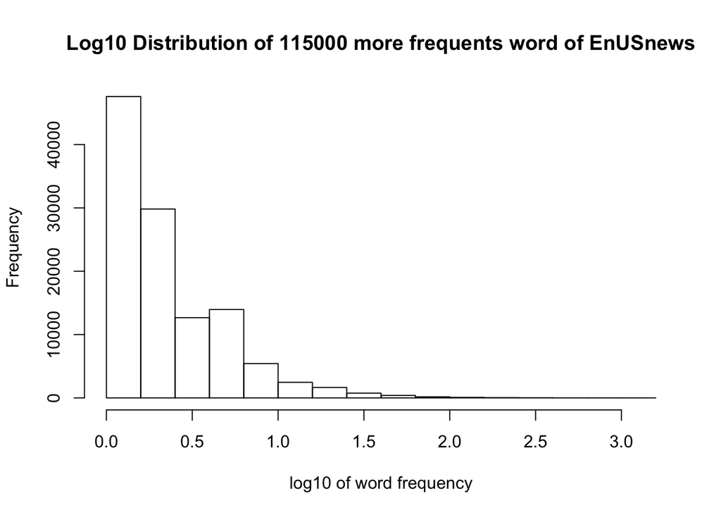

## Distribution of the frequencies of the vocabullary in En US tweets

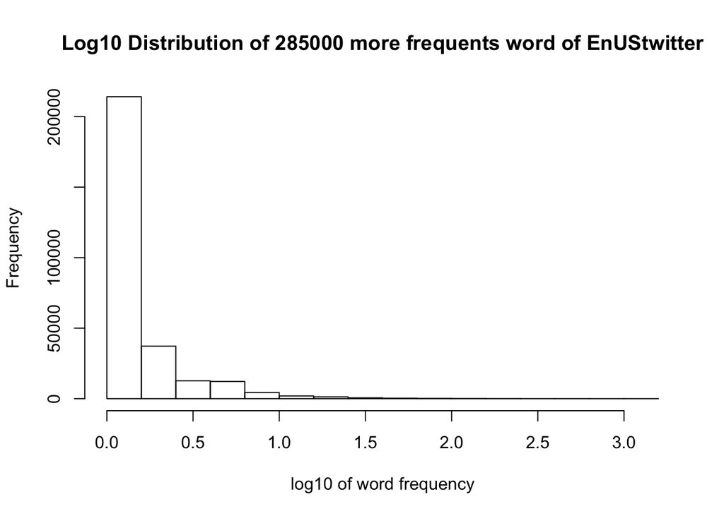

## Frequencies of word pair and triplet for EnUSblogs

```
## Time difference of 2.477655 mins
```

```
## Time difference of 43.77968 mins
```

```
## Time difference of 44.4201 mins
```

```
## Time difference of 52.09455 mins
```

```
## Time difference of 1.037578 hours
```

```
## Time difference of 1.197667 hours
```

```
## Time difference of 1.269924 hours
```

```
## Time difference of 1.451031 hours
```

```
## Time difference of 1.422261 hours
```

```
## Time difference of 1.742015 hours
```

### Word pairs stats

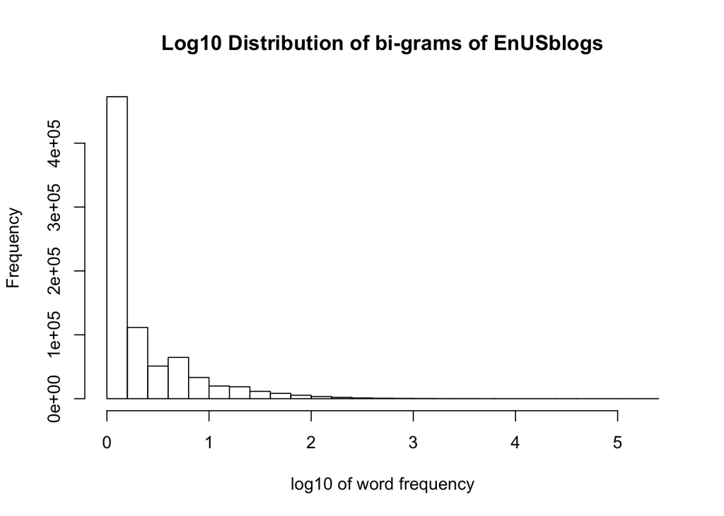

- The percentege of bigram used is 100%
- The percentege of the vocabullary that is cover by the bigram that have a frequency less or equal to 5 is 90.3641221%
- The percentege of the vocabullary that is cover by the bigram that have a frequency less or equal to 9 is 90.3641221%
- The percentege of bigram in the document that is cover by the 10K (1.2430343%) more frequent bigram is 57.2423079%
- The percentege of bigram in the document that is cover by the 2,7K (0.3356193%) more frequent bigram is 43.2957926%
- The percentege of bigram in the document that is cover by the 140 (0.0174025%) more frequent bigram is 20.5319551%
- The percentege of bigram in the document that is cover by the 15 (0.0018646%) more frequent bigram is 10.0153301%
- The 15 more frequent bigram are:

[output not shown]

### Word triplets stats

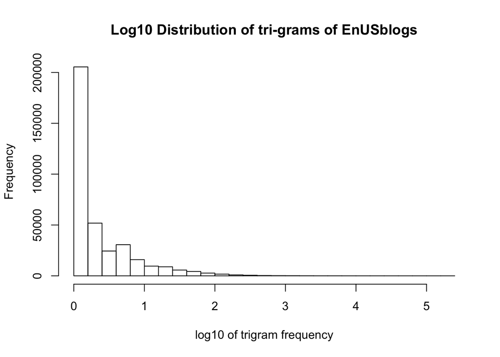

- The percentege of trigram used is 100%
- The percentege of the vocabullary that is cover by the trigram that have a frequency less or equal to 5 is 89.6100284%
- The percentege of the vocabullary that is cover by the trigram that have a frequency less or equal to 9 is 89.6100284%
- The percentege of trigram in the document that is cover by the 10K (2.7538423%) more frequent trigram is 66.6924885%
- The percentege of trigram in the document that is cover by the 2,7K (0.7435374%) more frequent trigram is 51.7644174%
- The percentege of trigram in the document that is cover by the 140 (0.0385538%) more frequent trigram is 26.8911246%
- The percentege of trigram in the document that is cover by the 15 (0.0041308%) more frequent trigram is 14.4758382%
- The 15 more frequent trigram are:

[output not shown]

## Distribution of the frequencies of the characters over the vocabullary

```
## [1] "Generating Corpus Character Freq."
```

```
##     user   system  elapsed
## 3303.212   20.350 3369.655
```

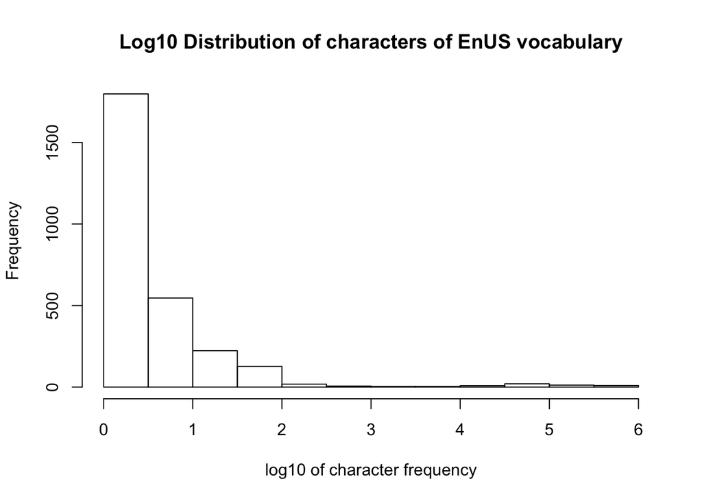

[figure not shown]

```
##   chr    Freq
## 1   I   41562
## 2   n   41562
## 3   e 1665818
## 4   h 1665818
## 5   t 1665818
## 6   a   33586
```

```
## [1] 4685264
```

```
##      chr V1
## 1        NA
## 2 \u0089 NA
## 3 \u0095 NA
## 4       ҉ NA
## 5 \u0088 NA
## 6        NA
```

```
## [1] 1507
```

## Distribution of the frequencies of the syllables over the vocabullary

```
## [1] "Generating CMU Dictionary."
```

```
##     user   system  elapsed
## 7400.086 1448.386 8874.903
```

```
## Time difference of 0.006846905 secs
```

```
## [1] "Loading previous hyphenation algorithm result."
```

Syllables using [CMU Pronouncing Dictionary](http://www.speech.cs.cmu.edu/cgi-bin/cmudict?in=Arpabet) Some facts:  
- Total of words in CMU Pronouncing Dictionary 133779.  
- Total of words in CMU Pronouncing Dictionary that are different pronunciation of the same word 8779.  
- Total of different words in CMU Pronouncing Dictionary are 125000.

# Task 3 - Build basic n-gram model & handle unseen n-grams

1. How can you efficiently store an n-gram model (think Markov Chains)?
2. How can you use the knowledge about word frequencies to make your model smaller and more efficient?
3. How many parameters do you need (i.e. how big is n in your n-gram model)?
4. Can you think of simple ways to “smooth” the probabilities (think about giving all n-grams a non-zero probability even if they aren’t observed in the data) ?
5. How do you evaluate whether your model is any good?
6. How can you use [backoff models](http://en.wikipedia.org/wiki/Katz%27s_back-off_model) to estimate the probability of unobserved n-grams?

# Task 4 - Build a predictive model & valuate the model for efficiency and accuracy

1. How does the model perform for different choices of the parameters and size of the model?
2. How much does the model slow down for the performance you gain?
3. Does perplexity correlate with the other measures of accuracy?
4. Can you reduce the size of the model (number of parameters) without reducing performance?

[CRAN Task View: Natural Language Processing](https://cran.r-project.org/web/views/NaturalLanguageProcessing.html)  
[Zipf’s law](https://en.wikipedia.org/wiki/Zipf%27s_law)  
[n-gram model](http://en.wikipedia.org/wiki/N-gram)  
[Google Books Ngram Viewer](http://storage.googleapis.com/books/ngrams/books/datasetsv2.html)  
[backoff models](http://en.wikipedia.org/wiki/Katz%27s_back-off_model)  
[Good–Turing frequency estimation](https://en.wikipedia.org/wiki/Good–Turing_frequency_estimation)